# RRBS_03 - Calculating differential methylation with MethylKit

Emma Bell

2020-04-29

# Summary

- Aim: To calculate differential methylation with MethylKit.
- Objectives:
  1. To filter, tile, and unite the processed RRBS data;
  2. To calculate differential methylation;
  3. To visualise the distribution of differential methylation values;
  4. To identify hypomethylated windows;
  5. To perform HOMER motif enrichment on the hypomethylated windows.

## Configuration

This analysis requires the following packages:

```r
library(readxl)
library(writexl)
library(vtree)
library(methylKit)
library(BiocParallel)
```

I use the `BiocParallel` package to parallelise R with the following parameters:

```r
param <- MulticoreParam(workers = 10, progressbar = TRUE)
```

This analysis requires the following R configuration object:

```r
r.config <- readRDS(file = file.path("code","r_config.RDS"))
```

## Metadata

```r
metadata <- read_excel(path = file.path(r.config$dirs$data.dir, "metadata.xlsx"), sheet = "RRBS")
metadata
```

| Sequencing ID | Donor ID | Donor ID (simple) | Stimulated | DAC |
| --- | --- | --- | --- | --- |
| 5700 | 28 | Donor 1 | Unstimulated | Untreated |
| 5701 | 28 | Donor 1 | Stimulated | Untreated |
| 5702 | 28 | Donor 1 | Stimulated | Treated |
| 5703 | 25 | Donor 2 | Unstimulated | Untreated |
| 5704 | 25 | Donor 2 | Stimulated | Untreated |
| 5705 | 25 | Donor 2 | Stimulated | Treated |
| H1 | 44 | Donor 3 | Unstimulated | Untreated |
| H2 | 44 | Donor 3 | Stimulated | Untreated |
| H3 | 44 | Donor 3 | Stimulated | Treated |

I’ll use the `vtree` package to visualise the experimental design.

```r
vtree(z = metadata, vars = c("Stimulated","DAC"))
```

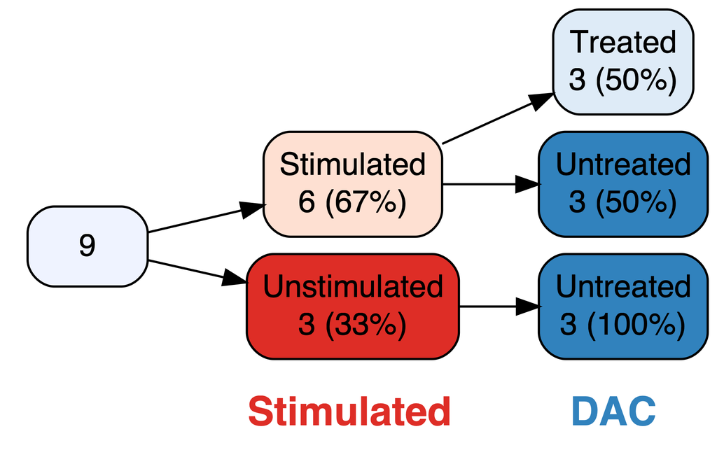

# Analysis

## 1. Filtering, tiling, and uniting the processed RRBS data

There are two comparisons we want to make:

1. Stimulated vs unstimulated;
2. Stimulated + DAC vs timulated.

To call differential expression for these two comparisons, I’ll create two separate objects containing subsets of the methylation data.

```r
meth.files <- list.files(path = file.path(r.config$dirs$augmented.data.dir,"01_rrbs_methylKit","01_meth_percentage"), pattern = "CpG.txt")
meth.files <- as.list(file.path(r.config$dirs$augmented.data.dir,"01_rrbs_methylKit","01_meth_percentage", meth.files))

meth.ids <- lapply(X = meth.files, FUN = function(X){
  this.meth <- X
  strsplit(x = this.meth, split = "/")[[1]][length(strsplit(x = this.meth, split = "/")[[1]])]
})

sample.names <- lapply(X = meth.ids, FUN = function(X){
  this.meth <- X
  strsplit(x = this.meth, split = "_")[[1]][1]
})

comparisons <- c("stimVsUnstim","dacVsStim")
treatment <- rep(c(0,1),3)

meth.data <- bplapply(X = comparisons, FUN = function(X){
   this.comparison <- X
   if(this.comparison=="stimVsUnstim"){
     index <- which(x = metadata$DAC == "Untreated")
   } else {
     index <- which(x = metadata$Stimulated == "Stimulated")
   }
   meth.to.read <- meth.files[index]
   meth.names <- sample.names[index]
   meth.reading <- methRead(location = meth.to.read, sample.id = meth.names, assembly="hg19", context = "CpG", treatment = treatment)
}, BPPARAM = param)
```

I’ll filter, tile, and unite both sets of samples.

```r
meth.unite <- bplapply(X = meth.data, FUN = function(X){
  methylObj <- X
  filtered <- filterByCoverage(methylObj = methylObj, lo.count = 10, lo.perc = NULL, hi.count = NULL, hi.perc = 99.9)
  tiled <- tileMethylCounts(object = filtered, win.size = 200, step.size = 200)
  unite <- unite(object = tiled, destrand = TRUE)
}, BPPARAM = param)
```

## 2. calculating differential methylation

```r
meth.diff <- bplapply(X = meth.unite, FUN = function(X){
  meth.base <- X
  meth.diff <- calculateDiffMeth(.Object = meth.base, mc.cores = 10)
}, BPPARAM = param)
```

I’ll write out the two `meth.diff` objects.

```bash
mkdir data/03_augmented/01_rrbs_methylKit/02_differential_methylation
```

```r
saveRDS(object = meth.diff[[1]], file = file.path(r.config$dirs$augmented.data.dir,"01_rrbs_methylKit","02_differential_methylation","methylKit_methDiff_StimVsUnstim.RDS"))
saveRDS(object = meth.diff[[2]], file = file.path(r.config$dirs$augmented.data.dir,"01_rrbs_methylKit","02_differential_methylation","methylKit_methDiff_StimDACVsStim.RDS"))
```

I’ll also write these out as a supplementary table.

```r
meth.df <- bplapply(X = meth.diff, FUN = function(X) getData(X), BPPARAM = param)
names(meth.df) <- comparisons
write_xlsx(x = meth.df, path = file.path(r.config$dirs$table.dir,"RRBS_SupplementaryTable_01.xlsx"), col_names = TRUE)
```

## 3. Visualising the distribution of differential methylation values

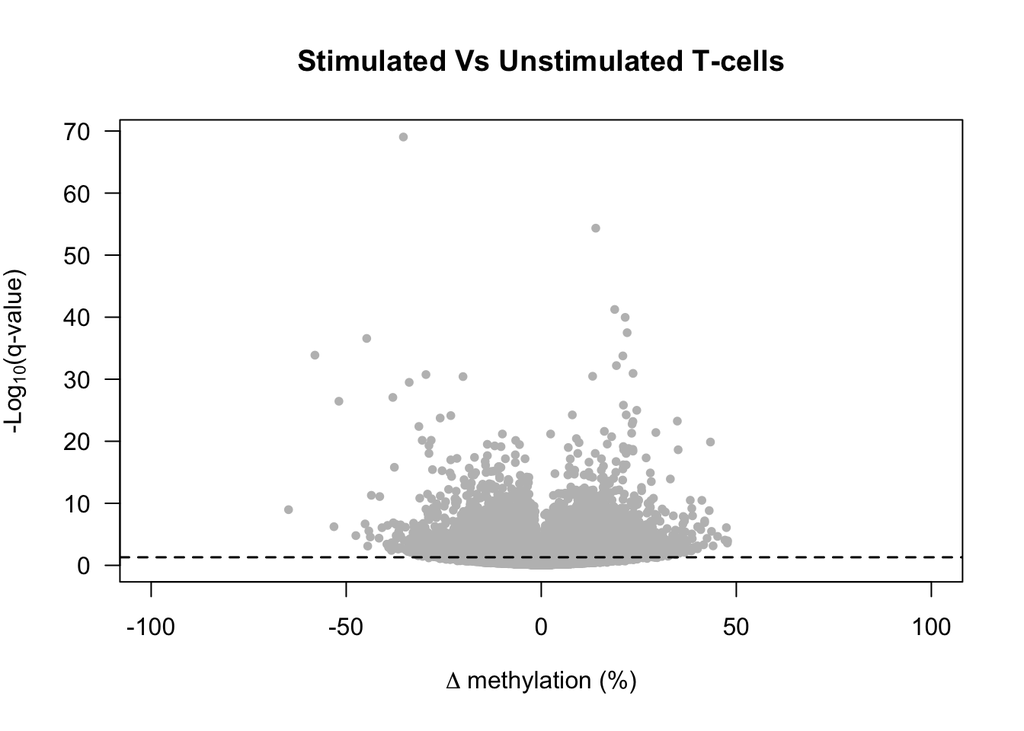

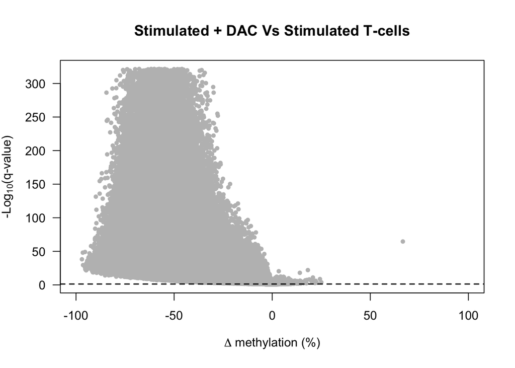

```r
main <- c("Stimulated Vs Unstimulated T-cells","Stimulated + DAC Vs Stimulated T-cells")
xlim <- c(-100,100)
xlab <- expression(paste(Delta," methylation (%)"))
ylab <- expression(paste("-Log"[10],"(q-value)"))

for(i in 1:length(meth.diff)){
  x <- meth.diff[[i]]$meth.diff
  q <- meth.diff[[i]]$qvalue
  y <- -log10(x = q)
  plot(x = x, y = y, xlim = xlim, xlab = xlab, ylab = ylab, col = "grey", pch = 20, las = 1, main = main[i])
  abline(h = -log10(0.05), lty = 2, lwd = 1.5)
}
```

```r
fig.names <- c("RRBS_03_volcano.png","RRBS_S03_volcano.png")
for(i in 1:length(meth.diff)){
  x <- meth.diff[[i]]$meth.diff
  q <- meth.diff[[i]]$qvalue
  y <- -log10(x = q)
  png.name <- file.path(r.config$dirs$figure.dir,fig.names[i])
  png(filename = png.name, width = 4.5, height = 4.5, units = r.config$fig.specs$units, res = r.config$fig.specs$res, pointsize = r.config$fig.specs$pointsize)
  plot(x = x, y = y, xlim = xlim, xlab = xlab, ylab = ylab, col = "grey", pch = 20, las = 1, main = main[i])
  abline(h = -log10(0.05), lty = 2, lwd = 1.5)
  dev.off()
}
```

## 4. Identifying hypomethylated windows

```r
signif <- meth.diff[[2]][which(meth.diff[[2]]$qvalue <= 0.05),]
dens <- density(x = signif$meth.diff)
this.min <- optimize(approxfun(dens$x,dens$y),interval=c(-50,0))$minimum
```

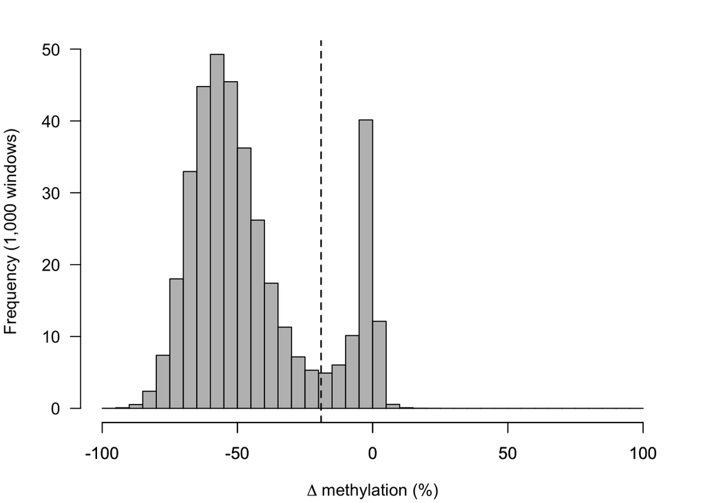

```r
xlim <- c(-100,100)
ylim <- c(0,50)
xlab <- expression(paste(Delta, " methylation (%)"))
par(mar = c(4,4,2,2))
hp <- hist(x = signif$meth.diff, plot = FALSE)
x.max <- round(max(hp$counts), -5)
hist(x = signif$meth.diff, col = "grey", main = "", xlim = xlim, las = 1, breaks = seq(-100,100,5), ylab = "Frequency (1,000 windows)", xlab = xlab, yaxt = "n")
axis(side = 1)
axis(side = 2, at = seq(0,50000,10000), labels = seq(0,50000,10000)/1000, las = 1)
abline(v = this.min, col = "black", lty = 2, lwd = 1.5)
```

```r
png.name <- file.path(r.config$dirs$figure.dir,"RRBS_04_signifDeltaMeth.png")
png(filename = png.name, width = 4.5, height = 4.5, units = r.config$fig.specs$units, res = r.config$fig.specs$res, pointsize = r.config$fig.specs$pointsize)
par(mar = c(4,4,1,1))
hist(x = signif$meth.diff, col = "grey", main = "", xlim = xlim, las = 1, breaks = seq(-100,100,5), axes = FALSE, ylab = "Frequency (1,000 windows)", xlab = xlab)
axis(side = 1)
axis(side = 2, at = seq(0,50000,10000), labels = seq(0,50000,10000)/1000, las = 1)
abline(v = this.min, col = "black", lty = 2, lwd = 1.5)
dev.off()
```

## 5. HOMER motif enrichment of the hypomethylated windows

I’ll create a bed file of all tiles within the library to compare against.

```r
tiles <- tileMethylCounts(object = meth.unite[[2]], win.size = 200, step.size = 200, mc.cores = 10)
tiles.bed <- data.frame(chromosome = tiles$chr, start = tiles$start, end = tiles$end, unique_peak_id = paste0("uid_",1:nrow(tiles)), not_used = "", strand = "*")
write.table(x = tiles.bed, file = file.path(r.config$dirs$augmented.data.dir,"02_rrbs_homer","RRBS_allTiles.bed"), quote = FALSE, sep = "\t", row.names = FALSE, col.names = FALSE)
```

I’ll now create a bed file of the statistically significantly hypomethylated tiles.

```r
signif.hypo <- signif[which(signif$meth.diff <= this.min),]
signif.tiles.bed <- data.frame(chromosome = signif.hypo$chr, start = signif.hypo$start, end = signif.hypo$end, unique_peak_id = paste0("uid_",1:nrow(signif.hypo)), not_used = "", strand = "*")
write.table(x = signif.tiles.bed, file = file.path(r.config$dirs$augmented.data.dir,"02_rrbs_homer","RRBS_signifHypoTiles.bed"), quote = FALSE, sep = "\t", row.names = FALSE, col.names = FALSE)
```

```bash
findMotifsGenome.pl data/03_augmented/02_rrbs_homer/RRBS_signifHypoTiles.bed hg19 data/03_augmented/02_rrbs_homer/01_signifHypoTilesVsAllTiles -size 200 -p 10 -bg data/03_augmented/02_rrbs_homer/RRBS_allTiles.bed
```

```r
homer <- read.table(file = file.path("data/03_augmented/02_rrbs_homer/01_signifHypoTilesVsAllTiles","knownResults.txt"), header = FALSE, sep = "\t", skip = 1, col.names = c("Motif","Consensus","P-value","Log P-value","q-value","N FG","PC FG","N BG","PC BG"), stringsAsFactors = FALSE)
head(homer)
```

|  | Motif | Consensus | P.value | Log.P.value | q.value | N.FG | PC.FG | N.BG | PC.BG |
| --- | --- | --- | --- | --- | --- | --- | --- | --- | --- |
| 1 | GSC(Homeobox)/FrogEmbryos-GSC-ChIP-Seq(DRA000576)/Homer | RGGATTAR | 0 | -18450 | 0 | 69692 | 22.82% | 7238.9 | 10.69% |
| 2 | Mef2c(MADS)/GM12878-Mef2c-ChIP-Seq(GSE32465)/Homer | DCYAAAAATAGM | 0 | -15560 | 0 | 36576 | 11.98% | 2846.0 | 4.20% |
| 3 | Mef2a(MADS)/HL1-Mef2a.biotin-ChIP-Seq(GSE21529)/Homer | CYAAAAATAG | 0 | -13870 | 0 | 33581 | 11.00% | 2652.5 | 3.92% |
| 4 | Bapx1(Homeobox)/VertebralCol-Bapx1-ChIP-Seq(GSE36672)/Homer | TTRAGTGSYK | 0 | -13380 | 0 | 105024 | 34.40% | 14563.4 | 21.51% |
| 5 | RARa(NR)/K562-RARa-ChIP-Seq(Encode)/Homer | TTGAMCTTTG | 0 | -11330 | 0 | 119468 | 39.13% | 18007.4 | 26.60% |
| 6 | GLIS3(Zf)/Thyroid-Glis3.GFP-ChIP-Seq(GSE103297)/Homer | CTCCCTGGGAGGCCN | 0 | -9410 | 0 | 110081 | 36.05% | 16838.2 | 24.87% |

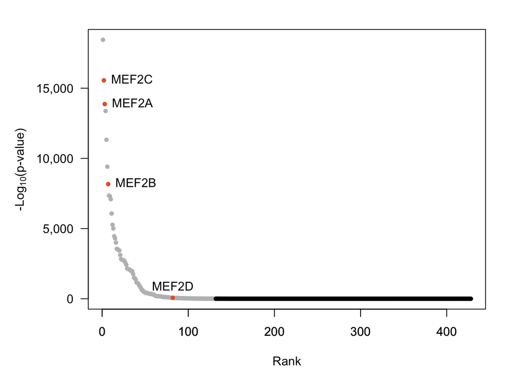

```r
mef.index <- grep(pattern = "Mef", x = homer$Motif, ignore.case = FALSE)
mef.name <- grep(pattern = "Mef", x = homer$Motif, ignore.case = FALSE, value = TRUE)
mef.name <- substr(x = mef.name, start = 1, stop = 5)
mef.name <- toupper(mef.name)
log.p <- homer$Log.P.value
log.p <- log.p * -1
point.col <- rep("black",nrow(homer))
point.col[which(homer$q.value < 0.05)] <- "grey"
ylab <- expression(paste("-Log"[10],"(p-value)"))
y.at <- seq(0,15000,5000)
y.labels <- prettyNum(x = y.at, big.mark = ",", big.interval = 3)
par(mar = c(4,6,2,2))
plot(x = 1:nrow(homer), y = log.p, xlab = "Rank", ylab = "", pch = 20, col = point.col, yaxt = "n")
axis(side = 1)
axis(side = 2, at = y.at, labels = y.labels, tick = TRUE, las = 1)
mtext(text = ylab, side = 2, line = 4)
points(x = mef.index, y = log.p[mef.index], pch = 20, col = r.config$simple.cols[3])
text(x = mef.index, y = log.p[mef.index], labels = mef.name, adj = 0, pos = c(4,4,4,3))
```

```r
png.name <- file.path(r.config$dirs$figure.dir,"RRBS_05_homerRanks.png")
png(filename = png.name, width = 4.5, height = 4.5, units = r.config$fig.specs$units, res = r.config$fig.specs$res, pointsize = r.config$fig.specs$pointsize)
par(mar = c(4,6,1,1))
plot(x = 1:nrow(homer), y = log.p, xlab = "Rank", ylab = "", pch = 20, col = point.col, yaxt = "n")
axis(side = 1)
axis(side = 2, at = y.at, labels = y.labels, tick = TRUE, las = 1)
mtext(text = ylab, side = 2, line = 4)
points(x = mef.index, y = log.p[mef.index], pch = 20, col = r.config$simple.cols[3])
text(x = mef.index, y = log.p[mef.index], labels = mef.name, adj = 0, pos = c(4,4,4,3))
dev.off()
```